# Practical Machine Learning for Weight Lifting HAR

Jason Huang

2017-10-10

## Overview

Base on [the data of weight lifting exercises](http://web.archive.org/web/20161224072740/http:/groupware.les.inf.puc-rio.br/har#dataset), we will train a predict model on the weight lifting training data with a machine learning algorithm, then we will use the trained predict model to recognize activity of weight lifting exercises.

## Code Book

classe - The fashions of Unilateral Dumbbell Biceps Curl

```
    Class A : exactly according to the specification
    Class B : throwing the elbows to the front
    Class C : lifting the dumbbell only halfway
    Class D : lowering the dumbbell only halfway
    Class E : throwing the hips to the front
```

belt/arm/forearm/dumbbell - The position of the sensing setup

roll/pitch/yaw - The Euler angles use to calculate features

accel - Accelerometer

gyros - Gyroscope

magnet - Magnetometer

avg(mean)/var(variance)/stddev(standard deviation)/max/min/amplitude/kurtosis/skewness - Mathematical algorithm

num_window/new_window - The parameters of sliding window approach

user_name - The name of the exerciser

raw_timestamp_part_1/raw_timestamp_part2/cvtd_timestamp - Timestamp

## Check and Clean data

[[Training Data]](https://d396qusza40orc.cloudfront.net/predmachlearn/pml-training.csv)  
[[Testing Data]](https://d396qusza40orc.cloudfront.net/predmachlearn/pml-testing.csv)

```r
  pml_training <- read.csv("pml-training.csv")
  pml_testing <- read.csv("pml-testing.csv")

  # Remove the columns all value is na in the testing set.
  training <- pml_training[,-which(apply(pml_testing,2,function(x)all(is.na(x))))]
  testing <- pml_testing[,-which(apply(pml_testing,2,function(x)all(is.na(x))))]

  # Remove the datas which new_window is true, because all new_window is no in testing set.
  training <- training[-which(training$new_window=='yes'),]

  # Remove the columns which no relation with classe.
  # removed columns : X, user_name, raw_timestamp_part_1, raw_timestamp_part2, cvtd_timestamp, num_window, new_window
  training <- training[, -c(1:7)]
  testing  <- testing[, -c(1:7)]
```

## Build Model

The traning model was built using the random forest method and 10-fold cross validation with center and scale preprocessing. A 10-fold cross validation was used to reduce the overfitting in random forest models.

```r
  library(caret)

  set.seed(100)

  modelFit <- train(classe~., data=training, ntree=150, preProcess=c("center","scale"), method="rf", trControl=trainControl(method="cv"))
```

```r
  print(modelFit)
```

```
## Random Forest
##
## 19216 samples
##    52 predictor
##     5 classes: 'A', 'B', 'C', 'D', 'E'
##
## Pre-processing: centered (52), scaled (52)
## Resampling: Cross-Validated (10 fold)
## Summary of sample sizes: 17294, 17293, 17295, 17295, 17296, 17294, ...
## Resampling results across tuning parameters:
##
##   mtry  Accuracy   Kappa
##    2    0.9950563  0.9937458
##   27    0.9953163  0.9940747
##   52    0.9905284  0.9880164
##
## Accuracy was used to select the optimal model using  the largest value.
## The final value used for the model was mtry = 27.
```

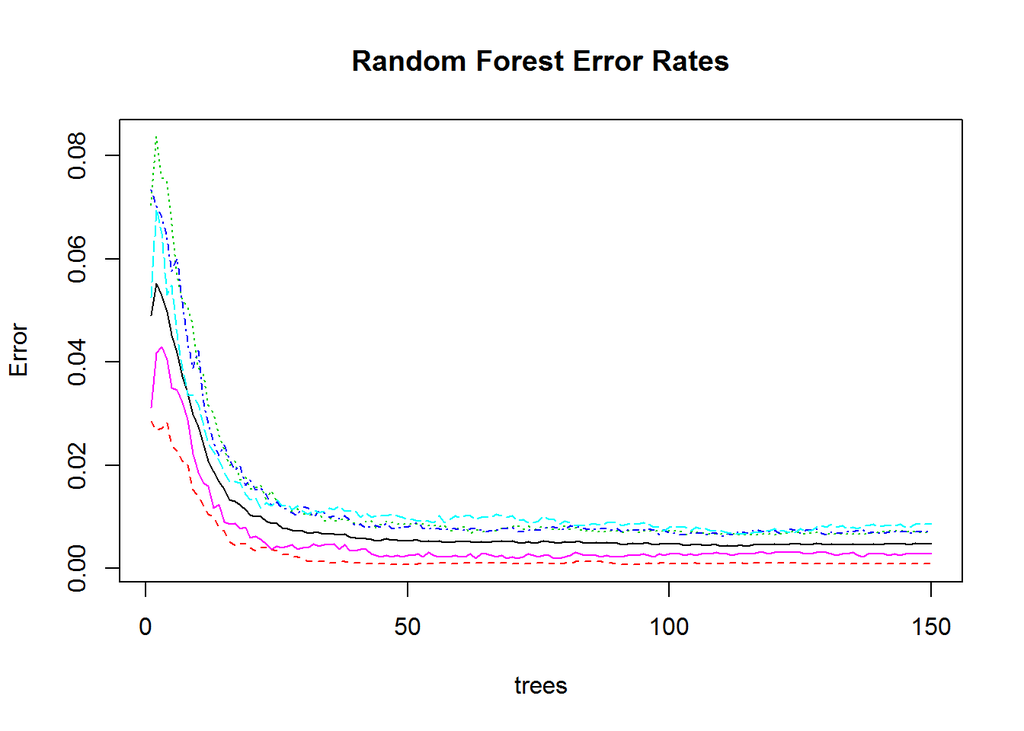

```r
  plot(modelFit$finalModel, main="Random Forest Error Rates")
```

## Prediction

Use the final model to predict on the testing dataset of 20 participants.

```r
  predict(modelFit, testing)
```

```
##  [1] B A B A A E D B A A B C B A E E A B B B
## Levels: A B C D E
```